# examples_1216

A proportional relationship can be represented by a line through the origin. If points $(0,0)$ and $(8, 20)$ are on a line, and so is point $(10,z)$, then what is the value of $z$?

You can set this up in two different ways...

$$\frac{20}{8}~=~\frac{z}{10}$$

or

$$\frac{10}{8}~=~\frac{z}{20}$$

Either way, you can start by using "cross multiplication".

$$10\cdot 20 = 8z$$

Divide both sides by $8$.

$$\frac{10\cdot 20}{8} = z$$

Now, I would find common factors in the numerator and denominator. The thorough approach is to find the prime factorization of each number.

$$\frac{\left(2^{1}\cdot5^{1}\right)\cdot
\left(2^{2}\cdot5^{1}\right)}{2^{3}} = z$$

Simplify the numerator.

$$\frac{2^{3}\cdot5^{2}}{2^{3}} =
z$$

Eliminate common factors.

$$5^{2} = z$$

Evaluate $z$.

$$z=25$$

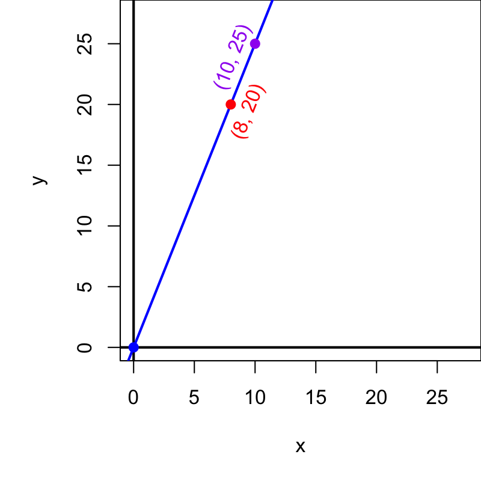

A proportional relationship can be represented by a line through the origin. If points $(0,0)$ and $(18, 27)$ are on a line, and so is point $(8,z)$, then what is the value of $z$?

You can set this up in two different ways...

$$\frac{27}{18}~=~\frac{z}{8}$$

or

$$\frac{8}{18}~=~\frac{z}{27}$$

Either way, you can start by using "cross multiplication".

$$8\cdot 27 = 18z$$

Divide both sides by $18$.

$$\frac{8\cdot 27}{18} = z$$

Now, I would find common factors in the numerator and denominator. The thorough approach is to find the prime factorization of each number.

$$\frac{\left(2^{3}\right)\cdot
\left(3^{3}\right)}{2^{1}\cdot3^{2}} = z$$

Simplify the numerator.

$$\frac{2^{3}\cdot3^{3}}{2^{1}\cdot3^{2}}
= z$$

Eliminate common factors.

$$2^{2}\cdot3^{1} = z$$

Evaluate $z$.

$$z=12$$

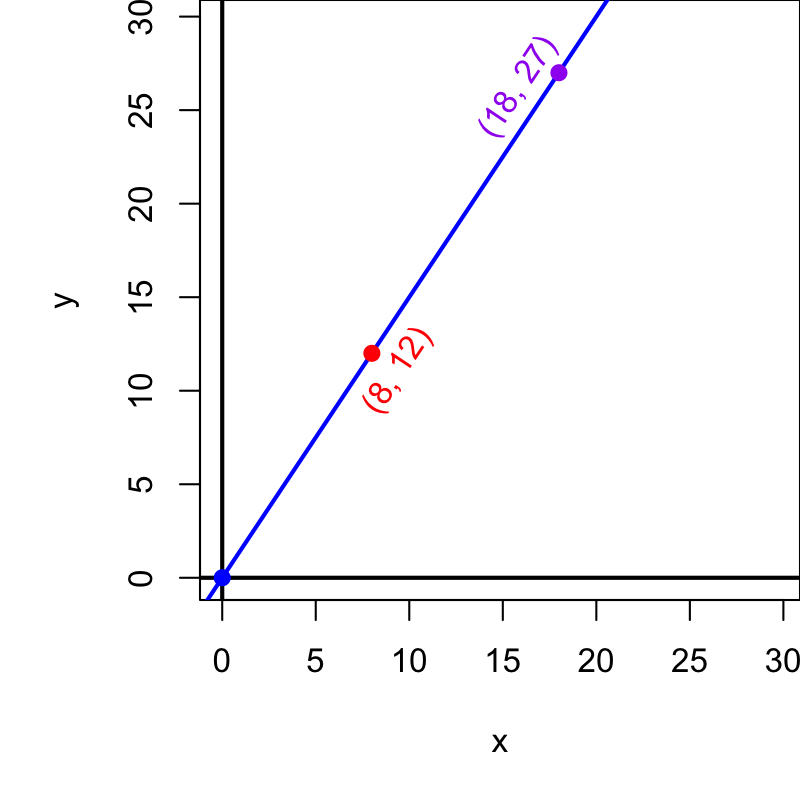

A proportional relationship can be represented by a line through the origin. If points $(0,0)$ and $(20, 30)$ are on a line, and so is point $(16,z)$, then what is the value of $z$?

You can set this up in two different ways...

$$\frac{30}{20}~=~\frac{z}{16}$$

or

$$\frac{16}{20}~=~\frac{z}{30}$$

Either way, you can start by using "cross multiplication".

$$16\cdot 30 = 20z$$

Divide both sides by $20$.

$$\frac{16\cdot 30}{20} = z$$

Now, I would find common factors in the numerator and denominator. The thorough approach is to find the prime factorization of each number.

$$\frac{\left(2^{4}\right)\cdot
\left(2^{1}\cdot3^{1}\cdot5^{1}\right)}{2^{2}\cdot5^{1}} =
z$$

Simplify the numerator.

$$\frac{2^{5}\cdot3^{1}\cdot5^{1}}{2^{2}\cdot5^{1}}
= z$$

Eliminate common factors.

$$2^{3}\cdot3^{1} = z$$

Evaluate $z$.

$$z=24$$

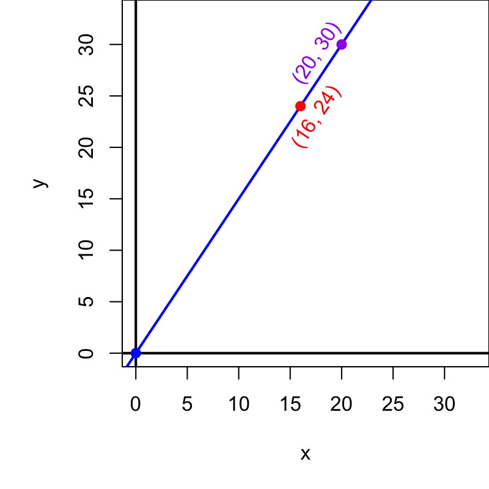

A proportional relationship can be represented by a line through the origin. If points $(0,0)$ and $(70, 63)$ are on a line, and so is point $(40,z)$, then what is the value of $z$?

You can set this up in two different ways...

$$\frac{63}{70}~=~\frac{z}{40}$$

or

$$\frac{40}{70}~=~\frac{z}{63}$$

Either way, you can start by using "cross multiplication".

$$40\cdot 63 = 70z$$

Divide both sides by $70$.

$$\frac{40\cdot 63}{70} = z$$

Now, I would find common factors in the numerator and denominator. The thorough approach is to find the prime factorization of each number.

$$\frac{\left(2^{3}\cdot5^{1}\right)\cdot
\left(3^{2}\cdot7^{1}\right)}{2^{1}\cdot5^{1}\cdot7^{1}} =
z$$

Simplify the numerator.

$$\frac{2^{3}\cdot3^{2}\cdot5^{1}\cdot7^{1}}{2^{1}\cdot5^{1}\cdot7^{1}}
= z$$

Eliminate common factors.

$$2^{2}\cdot3^{2} = z$$

Evaluate $z$.

$$z=36$$

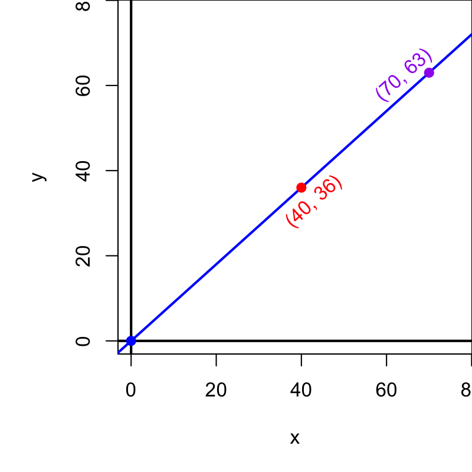

A proportional relationship can be represented by a line through the origin. If points $(0,0)$ and $(110, 70)$ are on a line, and so is point $(66,z)$, then what is the value of $z$?

You can set this up in two different ways...

$$\frac{70}{110}~=~\frac{z}{66}$$

or

$$\frac{66}{110}~=~\frac{z}{70}$$

Either way, you can start by using "cross multiplication".

$$66\cdot 70 = 110z$$

Divide both sides by $110$.

$$\frac{66\cdot 70}{110} = z$$

Now, I would find common factors in the numerator and denominator. The thorough approach is to find the prime factorization of each number.

$$\frac{\left(2^{1}\cdot3^{1}\cdot11^{1}\right)\cdot
\left(2^{1}\cdot5^{1}\cdot7^{1}\right)}{2^{1}\cdot5^{1}\cdot11^{1}} =
z$$

Simplify the numerator.

$$\frac{2^{2}\cdot3^{1}\cdot5^{1}\cdot7^{1}\cdot11^{1}}{2^{1}\cdot5^{1}\cdot11^{1}}
= z$$

Eliminate common factors.

$$2^{1}\cdot3^{1}\cdot7^{1} =
z$$

Evaluate $z$.

$$z=42$$

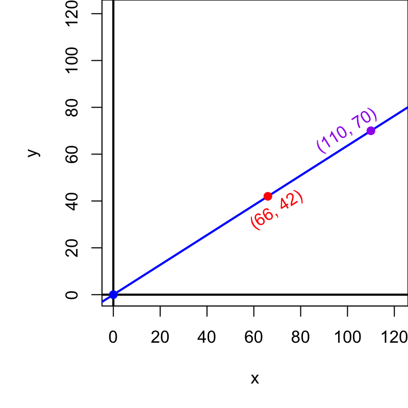

A proportional relationship can be represented by a line through the origin. If points $(0,0)$ and $(18, 63)$ are on a line, and so is point $(8,z)$, then what is the value of $z$?

You can set this up in two different ways...

$$\frac{63}{18}~=~\frac{z}{8}$$

or

$$\frac{8}{18}~=~\frac{z}{63}$$

Either way, you can start by using "cross multiplication".

$$8\cdot 63 = 18z$$

Divide both sides by $18$.

$$\frac{8\cdot 63}{18} = z$$

Now, I would find common factors in the numerator and denominator. The thorough approach is to find the prime factorization of each number.

$$\frac{\left(2^{3}\right)\cdot
\left(3^{2}\cdot7^{1}\right)}{2^{1}\cdot3^{2}} = z$$

Simplify the numerator.

$$\frac{2^{3}\cdot3^{2}\cdot7^{1}}{2^{1}\cdot3^{2}}
= z$$

Eliminate common factors.

$$2^{2}\cdot7^{1} = z$$

Evaluate $z$.

$$z=28$$

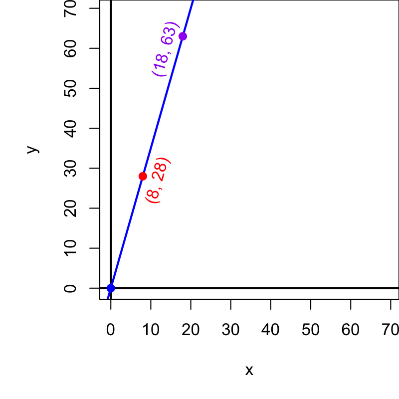

A proportional relationship can be represented by a line through the origin. If points $(0,0)$ and $(48, 44)$ are on a line, and so is point $(36,z)$, then what is the value of $z$?

You can set this up in two different ways...

$$\frac{44}{48}~=~\frac{z}{36}$$

or

$$\frac{36}{48}~=~\frac{z}{44}$$

Either way, you can start by using "cross multiplication".

$$36\cdot 44 = 48z$$

Divide both sides by $48$.

$$\frac{36\cdot 44}{48} = z$$

Now, I would find common factors in the numerator and denominator. The thorough approach is to find the prime factorization of each number.

$$\frac{\left(2^{2}\cdot3^{2}\right)\cdot
\left(2^{2}\cdot11^{1}\right)}{2^{4}\cdot3^{1}} = z$$

Simplify the numerator.

$$\frac{2^{4}\cdot3^{2}\cdot11^{1}}{2^{4}\cdot3^{1}}
= z$$

Eliminate common factors.

$$3^{1}\cdot11^{1} = z$$

Evaluate $z$.

$$z=33$$

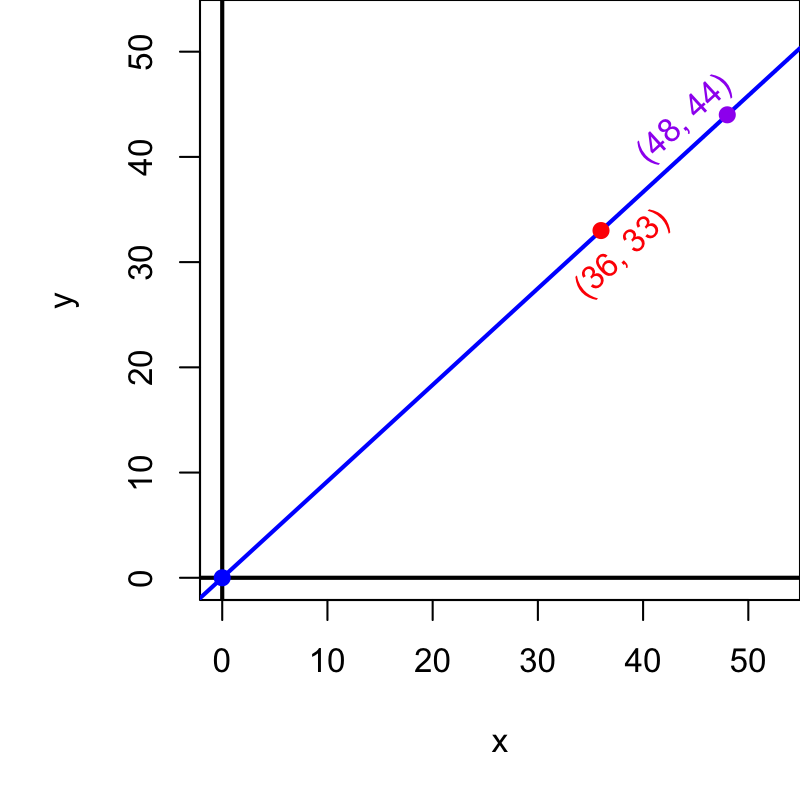

A proportional relationship can be represented by a line through the origin. If points $(0,0)$ and $(20, 30)$ are on a line, and so is point $(6,z)$, then what is the value of $z$?

You can set this up in two different ways...

$$\frac{30}{20}~=~\frac{z}{6}$$

or

$$\frac{6}{20}~=~\frac{z}{30}$$

Either way, you can start by using "cross multiplication".

$$6\cdot 30 = 20z$$

Divide both sides by $20$.

$$\frac{6\cdot 30}{20} = z$$

Now, I would find common factors in the numerator and denominator. The thorough approach is to find the prime factorization of each number.

$$\frac{\left(2^{1}\cdot3^{1}\right)\cdot
\left(2^{1}\cdot3^{1}\cdot5^{1}\right)}{2^{2}\cdot5^{1}} =
z$$

Simplify the numerator.

$$\frac{2^{2}\cdot3^{2}\cdot5^{1}}{2^{2}\cdot5^{1}}
= z$$

Eliminate common factors.

$$3^{2} = z$$

Evaluate $z$.

$$z=9$$

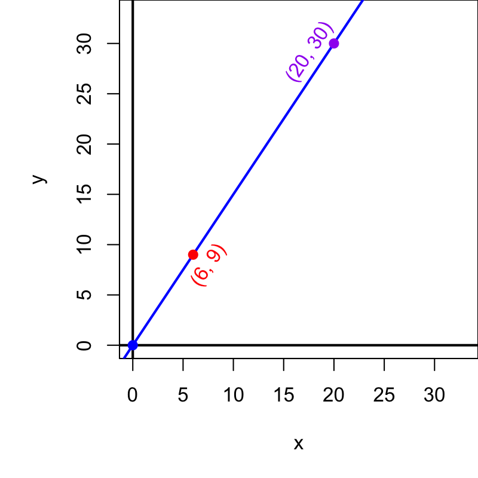